# CSC 4601: Lab on Decision Boundaries (Salvin)

In this lab, we explore how decision boundaries are used by machine learning methods to classify data. We primarily draw on popular machine learning data called the Iris Dataset. The author of the dataset measured the sepal and petal widths and lengths of 150 flowers from three species. The dataset has four numerical independent variables and a single categorical dependent variable (species).

### Problem 1

- **Question 1:** Just by looking at your plot, which of the three decision boundaries does the best job of separating the two classes of points?
- **Question 2:** Which of the three decision boundaries gave the more accurate predictions?
- **Question 3:** How does the accuracy metric seem to relate to the ability of the decision boundary to separate the classes?

**Answer 1:** it appears that decision boundary 2 does the best job of separating the two classes of points, because most of the blue points appear to be on the left side of the line and all of the yellow points appear to be on the right side of the line.

**Answer 2:** the accuracy of decision boundary appeared to be the highest at 0.993, however a honorouable mention would be decision boundary 1 which had a accuracy of 0.953.

**Answer 3:** the accuracy metric tells us how well the decision boundary separates the two classes. Hence, it is a good approach to find a decision boundary that separate two or more classes in a dataset.

### Problem 2

- **Question 1:** For which pair of features are the classes more easily separated?
- **Question 2:** Just by looking at your plots, for which pair of features does the decision boundary do a better job of separating the classes?
- **Question 3:** Which decision boundary gives the most accurate predictions?
- **Question 4:** How does the choice of features seem to impact the ability to make accurate predictions?

**Answer 1:** it would be petal length and petal width becuase it can be seen that they are visually separated, however, when we look at speal length and sepal width, we can see that the data points are visually mixed with each other to some extent.

**Answer 2:** from a visual observatiom, it would be the petal length vs petal width plot.

**Answer 3:** the decision boundary that gives the most accurate predictions would be the decision bounary used on the petal length vs petal width plot, which gives us a accuracy of 0.960 compared to sepal length vs speal width which gives a accuracy of 0.700.

**Answer 4:** the choice of features affects how separable the classes are in a feature space. Features that form a clear cluster in a scatter plot away from other clusters will give a higher accuracy value, but if there are features whose clusters intersect with each other heavily, it can lead to a much lower accuracy.

### Problem 3

- **Question 1:** Compare the accuracies you calculated from the training and testing datasets. Predictions for which dataset were evaluated as more accurate? Which accuracy score do you think is a more realistic representation of the performance of the model?
- **Question 2:** Look at the scatter plot of the validation data points. Will the model make errors in predicting the labels? Why?
- **Question 3:** Look at the scatter plots of the training and testing data points. Which data set is more representative of the validation data set? Which data set will demonstrate errors similar to the validation set?
- **Question 4:** Compare the accuracies you calculated from the training and testing data sets to the validation data set. Which accuracy calculation is more representative of the accuracy for the validation data set?
- **Question 5:** Explain why training and evaluating a model on the same data set can be deceptive.
- **Question 6:** Explain how dividing data into training and testing sets with no repeated points resolves some of the problems associated with training and evaluating a model on the same data set.
- **Question 7:** Name 3 potential ramifications for publishing a model that was trained and characterized using the same data set.

**Answer 1:** When it comes to the accuracy of the training dataset, it was 0.991. This was a very high accuracy compared to the accuracy of the testing dataset, which was 0.857. The accuracy for the testing dataset is more accurate because the accuracy is derived from using the model on testing data, which is otherwise data the model wasn't trained on

**Answer 3:** Looking at the scatter plot of the training and testing datasets, the testing dataset is more representative to the validation dataset and will demonstate error similar to the validation dataset because the decision boundary doesn't separate the classes well in the testing dataset but it does separate the classes well in the training dataset.

**Answer 4:** The accuracy of the training dataset is 0.991 and testing dataset is 0.857. The accuracy of the validation dataset is 0.864. This means that the testing dataset accuracy is more representative of the validation dataset due to a smaller magnitude in difference compared to the trianing dataset.

**Answer 5:** When we train and evaluate a model on the same dataset, the model will end up memorizing the specific data points instead of learning the patterns in the dataset. As a result, this will lead to overfitting and eventually a high misleading accuracy.

**Answer 6:** When we divide the data into training and testing sets with no repeated points, it allows us to evaluate the model on unseen data, and it forces the model to learn the patterns in the dataset. When we keep the data points non-repeated, the testing dataset provides an idea on how the model will perform on unseen data. As a result, we get a accuracy score that we can trust.

**Answer 7:** The ramifications of publishing a model trained and tested on the same dataset is a unrealiable high accuracy, poor model performance on unseen data and a overall low trust in the model to provide realiable predictions to those who use the model.

## Part I: Decision Boundaries and Evaluation of Model Predictions with Metrics

In this part, we load an visualize the `setosa_data.csv` dataset, plot its points colored by class, and draw the decision boundaries using their equations. We then rewrite each boundary in standard form, classify points using `linear_decision_boundary_classifier()` and evaluate the predictions with `sklearn.metrics.accuracy_score()`.

```python
"""

    a. load the "setosa_data.csv" using the Pandas read_csv() function
    b. display the first few rows of the DataFrame using the head() function

"""

# importing the required libraries
import pandas as pd

# loading the .csv file and displaying the first few rows
setosa_df = pd.read_csv("C:/GitHub/Semester 5/TheoryOfMachineLearning/4_week-four/lab/data/setosa_data.csv")
print(setosa_df.head(10))
```

```
        label  sepal_length (cm)  sepal_width (cm)
0  not setosa                5.1               3.5
1  not setosa                4.9               3.0
2  not setosa                4.7               3.2
3  not setosa                4.6               3.1
4  not setosa                5.0               3.6
5  not setosa                5.4               3.9
6  not setosa                4.6               3.4
7  not setosa                5.0               3.4
8  not setosa                4.4               2.9
9  not setosa                4.9               3.1
```

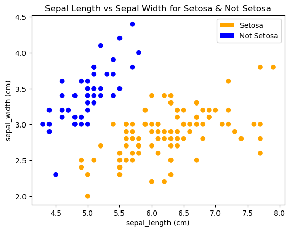

```python
"""

    c. create a scatter plot of the dataset points with the sepal length on the horizontal axis and sepal width on the vertical axis
        color each point by its class (orange -> setosa & blue -> not setosa)

"""

# importing the required libraries
import matplotlib.pyplot as plt
from matplotlib.patches import Patch

# mapping each class label to a color
colors = setosa_df['label'].map(lambda x: 'orange' if x == 'setosa' else 'blue')

# creating a scatter plot
plt.scatter(setosa_df['sepal_length (cm)'], setosa_df['sepal_width (cm)'], c=colors)

# setting up the legend
legend_elements = [Patch(facecolor='orange', label='Setosa'),
                   Patch(facecolor='blue', label='Not Setosa')]
plt.legend(handles=legend_elements)


plt.title("Sepal Length vs Sepal Width for Setosa & Not Setosa")
plt.xlabel("sepal_length (cm)")
plt.ylabel("sepal_width (cm)")
plt.show()
```

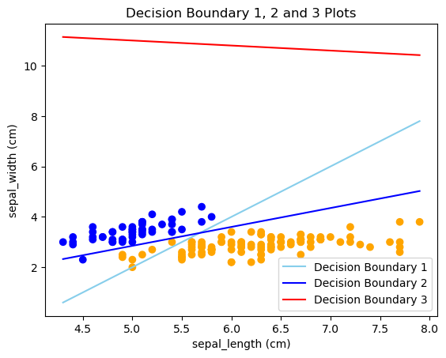

```python
"""

    d. plot the specified color and label the decision boundaries defined by the following equations:
        i. decision boundary 1 (black): x2 = 2 x1 - 8
        ii. decision boundary 2 (red): x2 = 0.75 x1 - 0.9
        iii. decision boundary 3 (purple): x2 = -0.2 x1 + 12

"""

# importing required libraries
import numpy as np

# i values
x1i = np.linspace(setosa_df['sepal_length (cm)'].min(), setosa_df['sepal_length (cm)'].max(), 100)
x2i = 2 * x1i - 8

# ii values
x1ii = np.linspace(setosa_df['sepal_length (cm)'].min(), setosa_df['sepal_length (cm)'].max(), 100)
x2ii = 0.75 * x1ii - 0.9

# iii values
x1iii = np.linspace(setosa_df['sepal_length (cm)'].min(), setosa_df['sepal_length (cm)'].max(), 100)
x2iii = -0.2 * x1iii + 12

# mapping each class label to a color
colors = setosa_df['label'].map(lambda x: 'orange' if x == 'setosa' else 'blue')

# creating a scatter plot
plt.scatter(setosa_df['sepal_length (cm)'], setosa_df['sepal_width (cm)'], c=colors)

# plot decision boundary 1 2 and 3
plt.plot(x1i, x2i, color='skyblue', label="Decision Boundary 1")
plt.plot(x1ii, x2ii, color='blue', label="Decision Boundary 2")
plt.plot(x1iii, x2iii, color='red', label="Decision Boundary 3")

# plotting details
plt.title("Decision Boundary 1, 2 and 3 Plots")
plt.xlabel("sepal_length (cm)")
plt.ylabel("sepal_width (cm)")
plt.legend()
plt.show()
```

```python
"""

    e. rewrite each decision boundary equation in a modified standard form
        w1x1 + w2x2 + w0 = 0

    f. import the linear_decision_boundary_classifier() function from the provided decision_boundaries.py file. Call the function for each
        decision boundary like so:

        dec_bound_vec = np.array([0.75, -1.0, -0.9])
        features = setosa_df[["sepal_length (cm)", "sepal_width (cm)"]].values
        true_labels = setosa_df["label"].values
        pred_labels = linear_decision_boundary_classifier(dec_bound_vec, features, true_labels, features)
        print(pred_labels)

"""

import sys
sys.path.append('./code')

# rewriting each decision boundary equation
    # i. x2 = 2 x1 - 8 --> 2 x1 - x2 - 8 = 0
    # ii. x2 = 0.75 x1 - 0.9 --> 0.75 x1 - x2 - 0.9 = 0
    # iii. x2 = -0.2 x1 + 12 --> -0.2 x1 - x2 + 12 = 0


# importing the linear decision boundary classifier
from decision_boundaries import linear_decision_boundary_classifier  # type: ignore


setosa_map = {'setosa' : 1, 'not setosa' : 0}
true_labels = setosa_df['label'].map(setosa_map).values
features = setosa_df[["sepal_length (cm)", "sepal_width (cm)"]].values

# decision boundary 1
dec_bound_vec_1 = np.array([2, -1, -8])
pred_labels_1 = linear_decision_boundary_classifier(dec_bound_vec_1, features, true_labels, features)

# print("Predicted Labels 1:")
# print(pred_labels_1, "\n")

# decision boundary 2
dec_bound_vec_2 = np.array([0.75, -1, -0.9])
pred_labels_2 = linear_decision_boundary_classifier(dec_bound_vec_2, features, true_labels, features)

# print("Predicted Labels 2")
# print(pred_labels_2, "\n")

# decision boundary 3
dec_bound_vec_3 = np.array([-0.2, -1, 12])
pred_labels_3 = linear_decision_boundary_classifier(dec_bound_vec_3, features, true_labels, features)

# print("Predicted Labels 3")
# print(pred_labels_3, "\n")
```

```
c:\GitHub\Semester 5\TheoryOfMachineLearning\4_week-four\lab\code\decision_boundaries.py:31: SmallSampleWarning: One or more sample arguments is too small; all returned values will be NaN. See documentation for sample size requirements.
  neg_label = mode(training_labels[neg_mask])[0]
```

```python
"""

    g. use the scikit-learn sklearn.metrics.accuracy_score() function to calculate and print the accuracy of the predictions using each decision
        boundary using the true and predicted labels

"""

# importing required libraries
from sklearn.metrics import accuracy_score

true_labels = np.array(true_labels)

# numpy data type to int data type
pred_labels_1 = np.array(pred_labels_1, dtype=int)
pred_labels_2 = np.array(pred_labels_2, dtype=int)
pred_labels_3 = np.array(pred_labels_3, dtype=int)

# classification accuracy
accuracy_1 = accuracy_score(true_labels, pred_labels_1)
accuracy_2 = accuracy_score(true_labels, pred_labels_2)
accuracy_3 = accuracy_score(true_labels, pred_labels_3)

# printing out results
print("Accuracy of Decision Boundary 1:", f"{accuracy_1:.3f}")
print("Accuracy of Decision Boundary 2:", f"{accuracy_2:.3f}")
print("Accuracy of Decision Boundary 3:", f"{accuracy_3:.3f}")
```

```
Accuracy of Decision Boundary 1: 0.953
Accuracy of Decision Boundary 2: 0.993
Accuracy of Decision Boundary 3: 0.667
```

## Part II: Predictive Power of Features

In this part, we load the "versicolor_virginica_data.csv" dataset, visualize it with scatter plots for both sepal and petal dimensions, and color points by class. We then define the decision boundaries for each feature pair, apply the `linear_decision_boundary_classifier()` to predict labels, and evaluate the preidtice accuracy using `sklearn.metrics.accuracy_score()`.

```python
"""

    a. load the dataset "versicolor_virginia_data.csv" using the pandas read_csv() function
    b. display the first few rows of the dataframe using the head() function

"""

# loading the dataset and displaying the first few rows
versicolor_df = pd.read_csv("C:/GitHub/Semester 5/TheoryOfMachineLearning/4_week-four/lab/data/versicolor_virginica_data.csv")
versicolor_df.head(10)
```

|  | label | sepal_length (cm) | sepal_width (cm) | petal_length (cm) | petal_width (cm) |
| --- | --- | --- | --- | --- | --- |
| 0 | versicolor | 7.0 | 3.2 | 4.7 | 1.4 |
| 1 | versicolor | 6.4 | 3.2 | 4.5 | 1.5 |
| 2 | versicolor | 6.9 | 3.1 | 4.9 | 1.5 |
| 3 | versicolor | 5.5 | 2.3 | 4.0 | 1.3 |
| 4 | versicolor | 6.5 | 2.8 | 4.6 | 1.5 |
| 5 | versicolor | 5.7 | 2.8 | 4.5 | 1.3 |
| 6 | versicolor | 6.3 | 3.3 | 4.7 | 1.6 |
| 7 | versicolor | 4.9 | 2.4 | 3.3 | 1.0 |
| 8 | versicolor | 6.6 | 2.9 | 4.6 | 1.3 |
| 9 | versicolor | 5.2 | 2.7 | 3.9 | 1.4 |

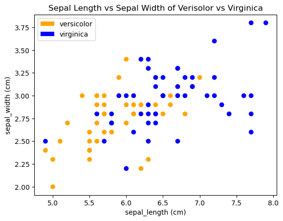

```python
"""

    c. create a scatter plot of the dataset points with the sepal length on the horizontal axis and the sepal width on the vertical axis
        color each point by its class (orange -> versicolor and blue -> virginica)

"""

# mapping each class label to a color
colors = versicolor_df['label'].map(lambda x: 'orange' if x == 'versicolor' else 'blue')


# creating a scatter plot
plt.scatter(versicolor_df['sepal_length (cm)'], versicolor_df['sepal_width (cm)'], c=colors)


# setting up the legend
legend_elements = [Patch(facecolor='orange', label='versicolor'),
                   Patch(facecolor='blue', label='virginica')]
plt.legend(handles=legend_elements)


# setting up the plotting details
plt.title("Sepal Length vs Sepal Width of Verisolor vs Virginica")
plt.xlabel("sepal_length (cm)")
plt.ylabel("sepal_width (cm)")
plt.show()
```

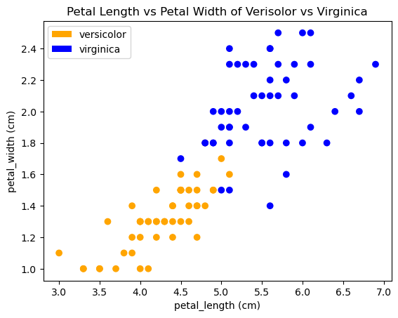

```python
"""

    d. create a second scatter plot of the dataset points with the petal length on the horizontal axis and the petal width on the vertical axis
        color each point point by its class (orange -> versicolor & blue -> virginica)

"""


# mapping each class label to a color
colors = versicolor_df['label'].map(lambda x: 'orange' if x == 'versicolor' else 'blue')


# creating a scatter plot
plt.scatter(versicolor_df['petal_length (cm)'], versicolor_df['petal_width (cm)'], c=colors)


# setting up the legend
legend_elements = [Patch(facecolor='orange', label='versicolor'),
                   Patch(facecolor='blue', label='virginica')]
plt.legend(handles=legend_elements)


# setting up the plotting details
plt.title("Petal Length vs Petal Width of Verisolor vs Virginica")
plt.xlabel("petal_length (cm)")
plt.ylabel("petal_width (cm)")
plt.show()
```

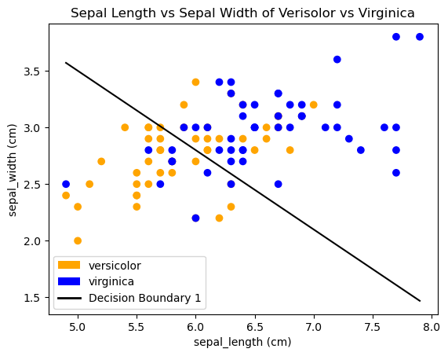

```python
"""

    e. for each pair of features, and plot and label the decision boundaries defined by the following equations:
        - decision boundary 1 -> black, sepal length and width --> x2 = -0.7 x1 + 7
        - decision boundary 2 -> black, petal length and width --> x2 = -0.7 x1 + 5

"""

# importing required libraries
from matplotlib.lines import Line2D

# ! scatter plot for sepal_length vs sepal_width

# the decision boundary
sepal_x1i = np.linspace(versicolor_df['sepal_length (cm)'].min(), versicolor_df['sepal_length (cm)'].max(), 100)
sepal_x2i = -0.7 * sepal_x1i + 7


# creating a scatter plot
plt.scatter(versicolor_df['sepal_length (cm)'], versicolor_df['sepal_width (cm)'], c=colors)
plt.plot(sepal_x1i, sepal_x2i, c="black")

# setting up the legend
legend_elements = [Patch(facecolor='orange', label='versicolor'),
                   Patch(facecolor='blue', label='virginica'),
                   Line2D([0], [0], color='black', lw=2, label='Decision Boundary 1')]
plt.legend(handles=legend_elements)


# setting up the plotting details
plt.title("Sepal Length vs Sepal Width of Verisolor vs Virginica")
plt.xlabel("sepal_length (cm)")
plt.ylabel("sepal_width (cm)")
plt.show()
```

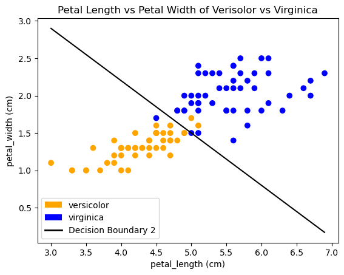

```python
"""

    e. for each pair of features, and plot and label the decision boundaries defined by the following equations:
        - decision boundary 1 -> black, sepal length and width --> x2 = -0.7 x1 + 7
        - decision boundary 2 -> black, petal length and width --> x2 = -0.7 x1 + 5

"""

# importing required libraries
from matplotlib.lines import Line2D

# ! scatter plot for petal_length vs petal_width

# the decision boundary
petal_x1i = np.linspace(versicolor_df['petal_length (cm)'].min(), versicolor_df['petal_length (cm)'].max(), 100)
petal_x2i = -0.7 * petal_x1i + 5

# creating a scatter plot
plt.scatter(versicolor_df['petal_length (cm)'], versicolor_df['petal_width (cm)'], c=colors)
plt.plot(petal_x1i, petal_x2i, c="black")

# setting up the legend
legend_elements = [Patch(facecolor='orange', label='versicolor'),
                   Patch(facecolor='blue', label='virginica'),
                   Line2D([0], [0], color='black', lw=2, label='Decision Boundary 2')]
plt.legend(handles=legend_elements)


# setting up the plotting details
plt.title("Petal Length vs Petal Width of Verisolor vs Virginica")
plt.xlabel("petal_length (cm)")
plt.ylabel("petal_width (cm)")
plt.show()
```

```python
"""

    f. rewrite each decision boundary equation in a modified standard form (keep fractions)
        w1x1 + w2x2 + w0 = 0

    g. import the linear_decision_boundary_classifier() function from the provided decision_boundaries.py file. We call the function with each
        pair of features and its associated decision boundary like so:

        dec_bound_vec = np.array([0.75, -1.0, -0.9])
        features = setosa_df[["sepal_length (cm)", "sepal_width (cm)"]].values
        true_labels = setosa_df["label"].values
        pred_labels = linear_decision_boundary_classifier(dec_bound_vec, features, true_labels, features)
        print(pred_labels)


"""

# rewriting each decision boundary equation
    # i. x2 = -0.7 x1 + 7 -> - 0.7x1 -x2 + 7 = 0
    # ii. x2 = -0.7 x1 + 5 -> -0.7x1 -x2 + 5 = 0

# typo found for some reason
versicolor_df['label'] = versicolor_df['label'].replace('virgnica', 'virginica')

# mapping and so on...
versicolor_map = {'versicolor' : 1, 'virginica' : 0}
true_labels = versicolor_df['label'].map(versicolor_map).astype(int).values

features_1 = versicolor_df[["sepal_length (cm)", "sepal_width (cm)"]].values
features_2 = versicolor_df[["petal_length (cm)", "petal_width (cm)"]].values

# decision boundary 1
dec_bound_vec_1 = np.array([-0.7, -1, 7])
pred_labels_3 = linear_decision_boundary_classifier(dec_bound_vec_1, features_1, true_labels, features_1)

# decision boundary 2
dec_bound_vec_2 = np.array([-0.7, -1, 5])
pred_labels_4 = linear_decision_boundary_classifier(dec_bound_vec_2, features_2, true_labels, features_2)
```

```python
"""

    h. use the scikit-learn sklearn.metrics.accuracy_score() function to calculate and print the accuracy of the predictions using each decision
    boundary using the true and predicted labels.

"""


true_labels = np.array(true_labels)

# numpy data type to int data type
pred_labels_3 = np.array(pred_labels_3, dtype=int)
pred_labels_4 = np.array(pred_labels_4, dtype=int)

# classification accuracy
accuracy_4 = accuracy_score(true_labels, pred_labels_3)
accuracy_5 = accuracy_score(true_labels, pred_labels_4)

# printing out results
print("Accuracy of Decision Boundary 1:", f"{accuracy_4:.3f}")
print("Accuracy of Decision Boundary 2:", f"{accuracy_5:.3f}")
```

```
Accuracy of Decision Boundary 1: 0.700
Accuracy of Decision Boundary 2: 0.960
```

## Part III: Experimental Setup with Train-Test Splitting

In this part, we look at the importance of splitting data into training, testing and validation sets to ensure models generalize well and avoid overfitting, using a spam filter and setosa / non-setosa classification as examples. This then demonstrates this with scatter plots of the three datasets and evaluates a given decision boundary on each set to compare prediction accuracies.

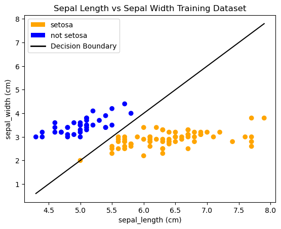

```python
"""

    a. create scatter plots of the validation, training and testing data points (3 separate plots). Put the sepal length on the horizontal axis
        and the sepal width on the vertical axis. Color each point by its class (orange --> setosa, blue --> not setosa)

        plot the following decision boundary on each plot
            x2 = 2x1 - 8

"""

# rewriting each decision boundary equation
    # x2 = 2x1 - 8 --> 2x1 - x2 - 8 = 0

training_df = pd.read_csv("C:/GitHub/Semester 5/TheoryOfMachineLearning/4_week-four/lab/data/setosa_training.csv")

# the decision boundary
sepal_x1i = np.linspace(training_df['sepal_length (cm)'].min(), training_df['sepal_length (cm)'].max(), 100)
sepal_x2i = 2 * sepal_x1i - 8

# the color palette
colors = training_df['label'].map(lambda x: 'orange' if x == 'setosa' else 'blue')


# creating a scatter plot
plt.scatter(training_df['sepal_length (cm)'], training_df['sepal_width (cm)'], c=colors)
plt.plot(sepal_x1i, sepal_x2i, c="black")

# setting up the legend
legend_elements = [Patch(facecolor='orange', label='setosa'),
                   Patch(facecolor='blue', label='not setosa'),
                   Line2D([0], [0], color='black', lw=2, label='Decision Boundary')]
plt.legend(handles=legend_elements)


# setting up the plotting details
plt.title("Sepal Length vs Sepal Width Training Dataset")
plt.xlabel("sepal_length (cm)")
plt.ylabel("sepal_width (cm)")
plt.show()
```

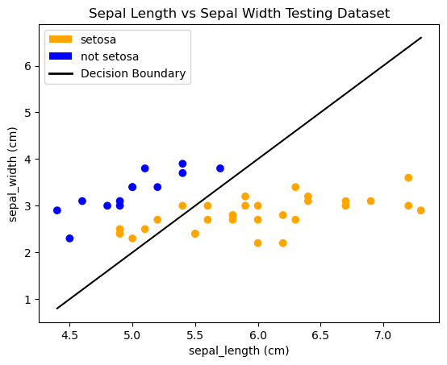

```python
"""

    a. create scatter plots of the validation, training and testing data points (3 separate plots). Put the sepal length on the horizontal axis
        and the sepal width on the vertical axis. Color each point by its class (orange --> setosa, blue --> not setosa)

        plot the following decision boundary on each plot
            x2 = 2x1 - 8

"""

# rewriting each decision boundary equation
    # x2 = 2x1 - 8 --> 2x1 - x2 - 8 = 0

testing_df = pd.read_csv("C:/GitHub/Semester 5/TheoryOfMachineLearning/4_week-four/lab/data/setosa_testing.csv")

# the decision boundary
sepal_x1i = np.linspace(testing_df['sepal_length (cm)'].min(), testing_df['sepal_length (cm)'].max(), 100)
sepal_x2i = 2 * sepal_x1i - 8

# the color palette
colors = testing_df['label'].map(lambda x: 'orange' if x == 'setosa' else 'blue')


# creating a scatter plot
plt.scatter(testing_df['sepal_length (cm)'], testing_df['sepal_width (cm)'], c=colors)
plt.plot(sepal_x1i, sepal_x2i, c="black")

# setting up the legend
legend_elements = [Patch(facecolor='orange', label='setosa'),
                   Patch(facecolor='blue', label='not setosa'),
                   Line2D([0], [0], color='black', lw=2, label='Decision Boundary')]
plt.legend(handles=legend_elements)


# setting up the plotting details
plt.title("Sepal Length vs Sepal Width Testing Dataset")
plt.xlabel("sepal_length (cm)")
plt.ylabel("sepal_width (cm)")
plt.show()
```

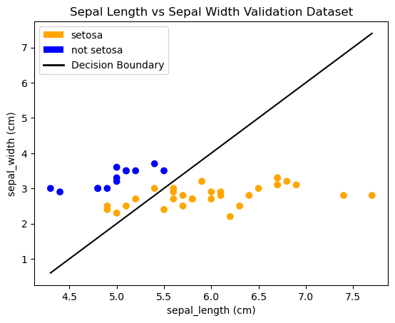

```python
"""

    a. create scatter plots of the validation, training and testing data points (3 separate plots). Put the sepal length on the horizontal axis
        and the sepal width on the vertical axis. Color each point by its class (orange --> setosa, blue --> not setosa)

        plot the following decision boundary on each plot
            x2 = 2x1 - 8

"""

# rewriting each decision boundary equation
    # x2 = 2x1 - 8 --> 2x1 - x2 - 8 = 0

validation_df = pd.read_csv("C:/GitHub/Semester 5/TheoryOfMachineLearning/4_week-four/lab/data/setosa_validation.csv")

# the decision boundary
sepal_x1i = np.linspace(validation_df['sepal_length (cm)'].min(), validation_df['sepal_length (cm)'].max(), 100)
sepal_x2i = 2 * sepal_x1i - 8

# the color palette
colors = validation_df['label'].map(lambda x: 'orange' if x == 'setosa' else 'blue')

# creating a scatter plot
plt.scatter(validation_df['sepal_length (cm)'], validation_df['sepal_width (cm)'], c=colors)
plt.plot(sepal_x1i, sepal_x2i, c="black")

# setting up the legend
legend_elements = [Patch(facecolor='orange', label='setosa'),
                   Patch(facecolor='blue', label='not setosa'),
                   Line2D([0], [0], color='black', lw=2, label='Decision Boundary')]
plt.legend(handles=legend_elements)


# setting up the plotting details
plt.title("Sepal Length vs Sepal Width Validation" \
" Dataset")
plt.xlabel("sepal_length (cm)")
plt.ylabel("sepal_width (cm)")
plt.show()
```

```python
"""

    evaluate the predictions for the given decision boundary using the pairs of datasets in the table below. Use the
    linear_decision_boundary_classifier() function to predict labels for the following datasets and the accuracy_score() function to evaluate
    the accuracies of the predictions

"""

# ! train on: training set | evaluate on: training set

# rewriting each decision boundary equation
    # x2 = 2x1 - 8 --> 2x1 - x2 - 8 = 0

# mapping and so on...
setosa_map = {'setosa' : 1, 'not setosa' : 0}

true_labels = training_df['label'].map(setosa_map).astype(int).values
features = training_df[["sepal_length (cm)", "sepal_width (cm)"]].values


# decision boundary
dec_bound_vec_1 = np.array([2, -1, -8])
pred_labels = linear_decision_boundary_classifier(dec_bound_vec_1, features, true_labels, features)


true_labels = np.array(true_labels)

# numpy data type to int data type
pred_labels = np.array(pred_labels, dtype=int)

# classification accuracy
accuracy = accuracy_score(true_labels, pred_labels)

# printing out results
print("Accuracy of Decision Boundary (Train vs Train):", f"{accuracy:.3f}")
```

```
Accuracy of Decision Boundary (Train vs Train): 0.991
```

```python
"""

    evaluate the predictions for the given decision boundary using the pairs of datasets in the table below. Use the
    linear_decision_boundary_classifier() function to predict labels for the following datasets and the accuracy_score() function to evaluate
    the accuracies of the predictions

"""

# ! train on: training set | evaluate on: testing set

# rewriting each decision boundary equation
    # x2 = 2x1 - 8 --> 2x1 - x2 - 8 = 0

# mapping and so on...
setosa_map = {'setosa' : 1, 'not setosa' : 0}

true_labels = training_df['label'].map(setosa_map).astype(int).values
features = training_df[["sepal_length (cm)", "sepal_width (cm)"]].values

test_labels = testing_df['label'].map(setosa_map).astype(int).values
test_features = testing_df[["sepal_length (cm)", "sepal_width (cm)"]].values


# decision boundary
dec_bound_vec_1 = np.array([2, -1, -8])
pred_labels = linear_decision_boundary_classifier(dec_bound_vec_1, features, true_labels, test_features) # ~ the training


true_labels = np.array(true_labels)

# numpy data type to int data type
pred_labels = np.array(pred_labels, dtype=int)

# classification accuracy
accuracy = accuracy_score(test_labels, pred_labels) # ~ the evaluating

# printing out results
print("Accuracy of Decision Boundary (Train vs Test):", f"{accuracy:.3f}")
```

```
Accuracy of Decision Boundary (Train vs Test): 0.857
```

```python
"""

    evaluate the predictions for the given decision boundary using the pairs of datasets in the table below. Use the
    linear_decision_boundary_classifier() function to predict labels for the following datasets and the accuracy_score() function to evaluate
    the accuracies of the predictions

"""

# ! train on: training set | evaluate on: validation set

# rewriting each decision boundary equation
    # x2 = 2x1 - 8 --> 2x1 - x2 - 8 = 0

# mapping and so on...
setosa_map = {'setosa' : 1, 'not setosa' : 0}

true_labels = training_df['label'].map(setosa_map).astype(int).values
features = training_df[["sepal_length (cm)", "sepal_width (cm)"]].values

validation_labels = validation_df['label'].map(setosa_map).astype(int).values
validation_features = validation_df[["sepal_length (cm)", "sepal_width (cm)"]].values


# decision boundary
dec_bound_vec_1 = np.array([2, -1, -8])
pred_labels = linear_decision_boundary_classifier(dec_bound_vec_1, features, true_labels, validation_features)


true_labels = np.array(true_labels)

# numpy data type to int data type
pred_labels = np.array(pred_labels, dtype=int)

# classification accuracy
accuracy = accuracy_score(validation_labels, pred_labels)

# printing out results
print("Accuracy of Decision Boundary (Train vs Validation):", f"{accuracy:.3f}")
```

```
Accuracy of Decision Boundary (Train vs Validation): 0.864
```